# Homework 3

*Ahmet Sualp Say - IE48B - Fall 2021*

```r
require(data.table)
require(ggplot2)
require(repr)
require(rpart)
require(rattle)
require(TSrepr)
require(TSdist)
require(dtw)
require(zoo)
require(e1071)

options(scipen=999)
options(repr.plot.width=15, repr.plot.height=8)
#memory.limit(size = 9999999999)
```

### Task: Comparison of NN classifiers with alternative representations

The aim of this task is to compare alternative distance measures for classification. Recall that distance calculations can be done using raw time series as well as the represented versions of them. You are expected to implement a pipeline that can evaluate alternative distance measures on different representation settings.

##### Alternative Representations with Alternative Parameter Settings:

- Raw Time Series
- Piecewise Aggregate Approximation
  - segment_length=5
  - segment_length=20
- Regression Trees
  - minsplit=20, minbucket=round(minsplit/3), cp=0.01, maxdepth=30 (default)
  - best ones selected through parameter tuning from the given set: (minsplit=15:20, cp=0, minbucket=5:7, maxdepth=25:30)

##### Classsifier Settings:

- kNN
  - k=1
  - k=3
  - k=5

###### Funtions to be used:

```r
# assuming you have the data in your working directory in the following format:
# 'working_directory/'
current_folder = getwd()
```

```r
# funtion to read & preprocess the data
preprocess = function(dataset, type, file_format, to_long=FALSE){
    # read the data
    data_path = sprintf("%s/%s_%s.%s", current_folder, dataset, type, file_format)
    data = fread(data_path)
    # first add id column
    data[,id:=1:.N]
    # second rename class column name as "class" then sort based on class
    setnames(data,'V1','class')
    data = data[order(class)]
    data[,class:=as.character(class)]
    # change data to long format for easier visualization and analysis
    if (to_long==TRUE){
        long = melt(data, id.vars=c('id','class'))
        # need to get numerical part of the variable (represents time)
        # using gsub to set the nonnumerical part to zero length
        long[,time:=as.numeric(gsub("\\D", "", variable))-1]
        long=long[,list(id,class,time,value)]
        long=long[order(id,time)]
        return(long)
    } else {
        return(data)
    }

}
```

```r
# table showing the performance (mean/std of accuracy) of best algorithm settings on each train set
bests_for_each_train_dataset = data.table()
# table showing the performance (mean/std of accuracy) of best algorithm settings on each test set
bests_for_each_test_dataset = data.table()
```

```r
# funtion to create representations for proposed types and if desired plot a sample with last_series_id
representation = function(data, long_data, last_series_id = 1, plot_represenations = TRUE){
    all_id_paa_rep = list()
    paa_rep = list()
    paa_rep_param = list()
    segment_length = c(5, 20)

    all_id_tree_rep = list()
    tree_rep = list()
    rpart.ranges =  list(minsplit=15:20, cp=0, minbucket=5:7, maxdepth=25:30)

    # calculate paa representation
    for (i in 1:last_series_id){
        iter = 1
        # calculate paa representation of one instance with proposed segment lenghts
        for (l in segment_length){
            # create table contains all time labels from the original data
            time_expanded = data.table(time = 1:(ncol(data)-1))
            # filter long_data for one instance
            data_ts = long_data[id==i]$value
            # calculate representation
            paa_rep_current = repr_paa(data_ts, l, meanC)
            # create dummy time to plot this representation
            dummy_time = c(1:(length(paa_rep_current)-1))*l
            dummy_time = c(dummy_time, (ncol(data)-1))
            # create table that contains the paa representations
            dt_paa = data.table(dummy_time, paa_rep_current)
            # speficy column name as representation name
            representation_name = paste0('paa_rep_sl=', l)
            names(dt_paa) = c("time", representation_name)
            representation = merge(time_expanded, dt_paa, by="time", all.x=T)
            # fill na values
            representation[,(representation_name):=nafill(get(representation_name),'nocb')]
            # store all paa representation of one instance with proposed settings
            paa_rep_param[[iter]] = representation
            iter=iter+1
        }
        # columnwise bind paa representation of one instance with all parameters setting
        id_representation = do.call(cbind, c(list(paa_rep_param[[1]][,.(time)]), lapply(paa_rep_param, `[`,,!c("time"))))
        id_representation[,id:=i]
        # change order of columns to make id first
        id_representation = id_representation[,c(4,1,2,3)]
        paa_rep[[i]] = id_representation

        default_rep = list()
        tuned_rep = list()
        tuned_models = list()

        # calculate tree representation
        selected_instance = long_data[id==i]

        # apply regression tree for each series with default model
        repr = rpart(value~time, long_data[id==i], control=rpart.control(minsplit=20,
                                                                         cp=0.01,
                                                                         minbucket=7,
                                                                         maxdepth=30))
        default_rep[[i]] = repr
        # fit values with default model for instance i
        selected_instance[,tree_rep_default:=predict(default_rep[[i]], selected_instance)]
        # make crossvalidation, and take the best parameteres which gives the least error. The default is k = 10 folds.
        tree_tune = tune(rpart, value~time, data=long_data[id==i], ranges=rpart.ranges)
        tuned_models[[i]] = tree_tune
        # apply regression tree for each series with tuned model
        repr = rpart(value~time, long_data[id==i], control=rpart.control(minsplit=tuned_models[[i]]$best.parameters[,1],
                                                                         cp=0,
                                                                         minbucket=tuned_models[[i]]$best.parameters[,3]),
                                                                         maxdepth=tuned_models[[i]]$best.parameters[,4])
        tuned_rep[[i]] = repr
        # fit values with regression tree with tuned model
        selected_instance[,tree_rep_tuned:=predict(tuned_rep[[i]], selected_instance)]
        # construct tree representation of instance i and add to list
        tree_rep[[i]] = selected_instance

    }

    # bind all paa representations of all instances with proposed settings
    all_id_paa_rep = do.call(rbind, paa_rep)

    # bind all tree representations of all instances with proposed settings
    all_id_tree_rep = do.call(rbind, tree_rep)

    # all representations
    all_rep = merge(all_id_tree_rep,
                    all_id_paa_rep,
                    by=c("id", "time"))

    if (plot_represenations==TRUE){
        data_plot = all_rep[id==last_series_id]
        data_plot = melt(data_plot,id.vars='time', measure.vars=c('value','tree_rep_default','tree_rep_tuned','paa_rep_sl=5', 'paa_rep_sl=20'))
        ggplot(data_plot,aes(x=time,y=value,color=variable)) + geom_line(size=1)

    } else {
        return(all_rep)
    }

}
```

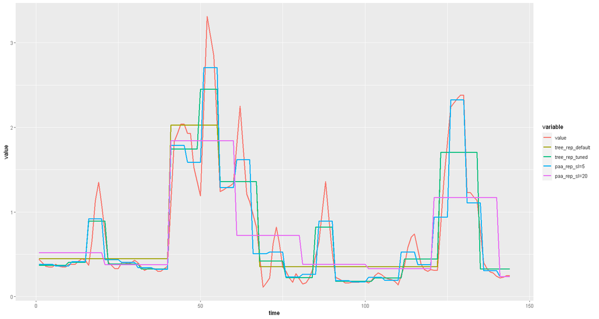

```r
# Example run of the function:
# Function will calculate the all representations for series1 and return plot of them since the plot_represenations=TRUE
representation(data=train_data, long_data=train_data_long, last_series_id = 1, plot_represenations = TRUE)
```

```r
# Example run of the function:
# One can change last_series_id as nrow(input_data) <or any id that wants to calculate last select and plot_represenations = FALSE
# then function will return a list containing all representations of all series until last_series_id in long format
reps = representation(data=train_data, long_data=train_data_long, last_series_id = 2, plot_represenations = FALSE)
head(reps)
```

| id | time | class | value | tree_rep_default | tree_rep_tuned | paa_rep_sl=5 | paa_rep_sl=20 |
| --- | --- | --- | --- | --- | --- | --- | --- |
| 1 | 1 | 1 | 0.44 | 0.44825 | 0.384375 | 0.380 | 0.519 |
| 1 | 2 | 1 | 0.40 | 0.44825 | 0.384375 | 0.380 | 0.519 |
| 1 | 3 | 1 | 0.36 | 0.44825 | 0.384375 | 0.380 | 0.519 |
| 1 | 4 | 1 | 0.35 | 0.44825 | 0.384375 | 0.380 | 0.519 |
| 1 | 5 | 1 | 0.35 | 0.44825 | 0.384375 | 0.380 | 0.519 |
| 1 | 6 | 1 | 0.38 | 0.44825 | 0.384375 | 0.364 | 0.519 |

```r
large_number=10000

# function to calculate proposed distances of raw time series and proposed representations
distance = function(dataset, reps, rep_names, dist_names, type){
    iter = 1
    for (i in rep_names){
        dt = as.data.table(reps[iter])
        if ("euc" %in% dist_names) {
        # remove id variable from the dt
        dist_euc = as.matrix(dist(dt[,2:ncol(dt)]))
        diag(dist_euc) = large_number
        fwrite(dist_euc, sprintf('hw3_%s_%s_euc_%s_dist.csv', type, dataset, i), col.names=F)
        }
        if ("dtw" %in% dist_names){
        dist_dtw = as.matrix(dtwDist(dt[,2:ncol(dt)]))
        diag(dist_dtw) = large_number
        fwrite(dist_dtw, sprintf('hw3_%s_%s_dtw_%s_dist.csv', type, dataset, i), col.names=F)
        }
        if ("lcss" %in% dist_names){
        dist_lcss = TSDatabaseDistances(dt[,2:ncol(dt)], distance='lcss', epsilon=0.05)
        dist_lcss = as.matrix(dist_lcss)
        diag(dist_lcss) = large_number
        fwrite(dist_lcss, sprintf('hw3_%s_%s_lcss_%s_dist.csv', type, dataset, i), col.names=F)
        }
        if ("erp" %in% dist_names){
        dist_erp = TSDatabaseDistances(dt[,2:ncol(dt)], distance='erp', g=0.5)
        dist_erp = as.matrix(dist_erp)
        diag(dist_erp) = large_number
        fwrite(dist_erp, sprintf('hw3_%s_%s_erp_%s_dist.csv', type, dataset, i), col.names=F)
        }
        iter = iter + 1
    }

}
```

```r
# function to find nearest neighbours
nn_classify = function(dist_matrix, train_classes, test_indices, k=1){

    test_distances_to_train = dist_matrix[test_indices,]
    test_distances_to_train = test_distances_to_train[,-test_indices]
    train_classes = train_classes[-test_indices]
    # order the distances of each instance to another
    ordered_neighbours = apply(test_distances_to_train, 1, order)
    if(k==1){
        nearest_class = as.numeric(ordered_neighbours[as.numeric(ordered_neighbours[1,])])
        nearest_class = data.table(id=test_indices, nearest_class)
    } else {
        # returns each classes' k nearest neighbours
        nearest_class = apply(ordered_neighbours[1:k,], 2, function(x) {train_classes[x]})
        nearest_class = data.table(id=test_indices, t(nearest_class))
    }

    long_nn_class = melt(nearest_class,'id')

    # count the classes of nearest neighbours for each instance
    class_counts = long_nn_class[,.N,list(id,value)]
    # calculate the frequency of each neigbour
    class_counts[,predicted_prob:=N/k]
    wide_class_prob_predictions = dcast(class_counts, id~value, value.var='predicted_prob')
    wide_class_prob_predictions[is.na(wide_class_prob_predictions)]=0
    # returns class which has higher probability (i.e most frequent class) as predicted value
    class_predictions = class_counts[,list(predicted = value[which.max(N)]), by=list(id)]

    return(list(prediction = class_predictions, prob_estimates = wide_class_prob_predictions))

}
```

#### Dataset 1: PowerCons (Train)

```r
dataset = "PowerCons"
type = "TRAIN"
file_format = "txt"
```

```r
train_data = preprocess(dataset=dataset, type=type, file_format=file_format, to_long=FALSE)
train_data_long = preprocess(dataset=dataset, type=type, file_format=file_format, to_long=TRUE)
```

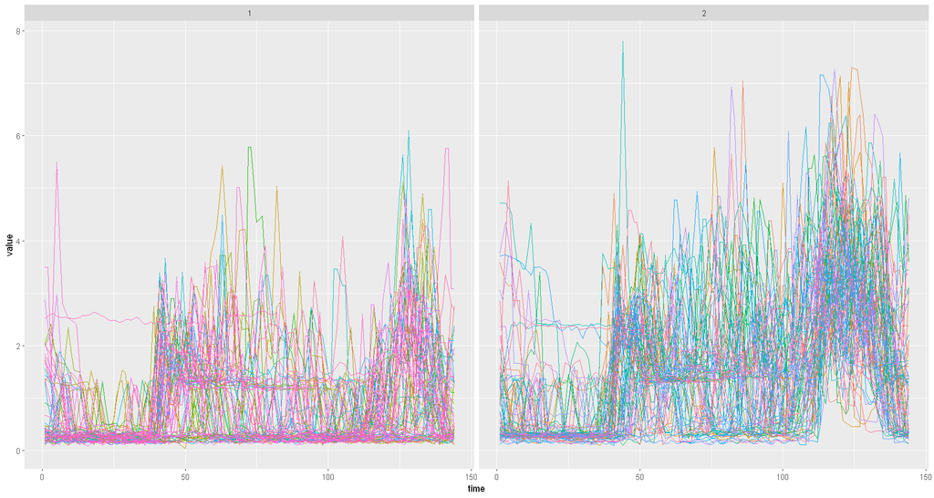

```r
# visualize time series based on class
ggplot(train_data_long, aes(time, value)) + geom_line(aes(color = as.character(id)), show.legend = FALSE) +
     facet_wrap(~class)
```

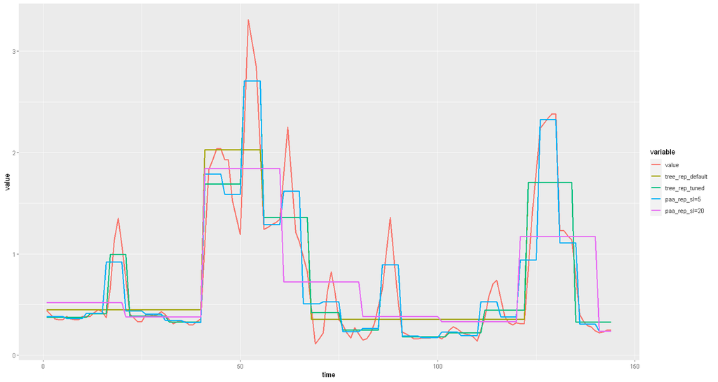

```r
representation(data=train_data, long_data=train_data_long, last_series_id = 1, plot_represenations = TRUE)
```

```r
# calculate representations for whole dataset
reps = representation(data=train_data, long_data=train_data_long, last_series_id = nrow(train_data), plot_represenations = FALSE)
fwrite(reps, sprintf('hw3_reps_%s_%s.csv', type, dataset), col.names=TRUE)
```

```r
# Create a overall accuracy table to find performance of representations and select the best setting among each representations
reps = fread(sprintf('hw3_reps_%s_%s.csv', type, dataset))
mse = melt(reps, id.vars=c("id", "class", "time"), measure.vars=c("value","tree_rep_default","tree_rep_tuned","paa_rep_sl=5", "paa_rep_sl=20"))
mse[,class:=as.character(class)]
mse = merge(mse, train_data_long[,list(id, class, time, obs=value)], by=c("id",  "class", "time"))
mse[!(variable=="value"), list(mse=mean((value-obs)^2)),list(variable)]
```

| variable | mse |
| --- | --- |
| tree_rep_default | 0.1516975 |
| tree_rep_tuned | 0.1118470 |
| paa_rep_sl=5 | 0.1228113 |
| paa_rep_sl=20 | 0.3906024 |

###### Between tree representations tree_rep_tuned, between paa representation sl=5 will be selected

```r
# change selected raw_series and selected representations to long format and store it in a list
raw_series = dcast(reps[,c(1,2,3,4)], id ~ time, value.var = "value")
tree_rep_tuned = dcast(reps[,c(1,2,3,6)], id ~ time, value.var = "tree_rep_tuned")
paa_rep_sl_5 = dcast(reps[,c(1,2,3,7)], id ~ time, value.var = "paa_rep_sl=5")
train_representation_list = list(raw_series, tree_rep_tuned, paa_rep_sl_5)
```

```r
distance(dataset = dataset, reps = train_representation_list, rep_names = c("raw", "tree_rep_tuned", "paa_rep_sl=5"), dist_names = c("euc", "dtw", "lcss", "erp"),  type = type)
```

[output not shown]

```r
dist_files = list.files(pattern = paste0("hw3_TRAIN_", dataset))
dist_files
```

1. 'hw3_TRAIN_PowerCons_dtw_paa_rep_sl=5_dist.csv'

2. 'hw3_TRAIN_PowerCons_dtw_raw_dist.csv'

3. 'hw3_TRAIN_PowerCons_dtw_tree_rep_tuned_dist.csv'

4. 'hw3_TRAIN_PowerCons_erp_paa_rep_sl=5_dist.csv'

5. 'hw3_TRAIN_PowerCons_erp_raw_dist.csv'

6. 'hw3_TRAIN_PowerCons_erp_tree_rep_tuned_dist.csv'

7. 'hw3_TRAIN_PowerCons_euc_paa_rep_sl=5_dist.csv'

8. 'hw3_TRAIN_PowerCons_euc_raw_dist.csv'

9. 'hw3_TRAIN_PowerCons_euc_tree_rep_tuned_dist.csv'

10. 'hw3_TRAIN_PowerCons_lcss_paa_rep_sl=5_dist.csv'

11. 'hw3_TRAIN_PowerCons_lcss_raw_dist.csv'

12. 'hw3_TRAIN_PowerCons_lcss_tree_rep_tuned_dist.csv'

```r
require(TunePareto)

k_levels = c(1, 3, 5)
set.seed(2021)
# 5 repeats of stratified 10-fold cross-validation
nof_rep = 5
n_fold = 10

result = vector('list',length(dist_files)*nof_rep*n_fold*length(k_levels))

# create test indices to be used in cross-validation
train_classes = train_data$class
cv_indices = generateCVRuns(train_classes, ntimes = nof_rep, nfold = n_fold, leaveOneOut = FALSE, stratified = TRUE)

iter=1
# loop to calculate best k value for nearest neighbour with 10-fold-cross-validation, returns accuracy of each run in each fold
for(m in 1:length(dist_files)){
    dist_mat = as.matrix(fread(dist_files[m], header=FALSE))

    for(i in 1:nof_rep){
        this_fold = cv_indices[[i]]

        for(j in 1:n_fold){
            test_indices = this_fold[[j]]

            for(k in 1:length(k_levels)){
                current_k = k_levels[k]
                current_fold = nn_classify(dist_mat, train_classes, test_indices, k = current_k)
                accuracy = sum(train_classes[test_indices]==current_fold$prediction$predicted)/length(test_indices)
                distance_representation_name =  gsub("hw3_TRAIN_PowerCons_", "", dist_files[m])
                tmp = data.table(representation = gsub("hw3_TRAIN_PowerCons_", "", dist_files[m]), distance_measure = gsub("hw3_TRAIN_PowerCons_", "", dist_files[m]), repid = i, foldid = j, k = current_k, acc = accuracy)
                result[[iter]] = tmp
                iter=iter+1

            }

        }

    }

}

overall_results = rbindlist(result)
summary = overall_results[,list(avg_accuracy = mean(acc), sdev_accuracy=sd(acc)), by=list(distance_measure, k)]
summary[order(-avg_accuracy)]
```

| distance_measure | k | avg_accuracy | sdev_accuracy |
| --- | --- | --- | --- |
| erp_raw_dist.csv | 5 | 0.627777778 | 0.102408634 |
| erp_tree_rep_tuned_dist.csv | 3 | 0.615555556 | 0.093124699 |
| erp_tree_rep_tuned_dist.csv | 5 | 0.607777778 | 0.090775056 |
| euc_raw_dist.csv | 5 | 0.605555556 | 0.089966540 |
| erp_raw_dist.csv | 3 | 0.598888889 | 0.097389716 |
| erp_paa_rep_sl=5_dist.csv | 5 | 0.584444444 | 0.088548100 |
| erp_paa_rep_sl=5_dist.csv | 3 | 0.582222222 | 0.098002216 |
| dtw_paa_rep_sl=5_dist.csv | 5 | 0.581111111 | 0.109518058 |
| euc_paa_rep_sl=5_dist.csv | 5 | 0.578888889 | 0.097905760 |
| dtw_tree_rep_tuned_dist.csv | 5 | 0.577777778 | 0.101015254 |
| euc_tree_rep_tuned_dist.csv | 5 | 0.575555556 | 0.106337360 |
| dtw_paa_rep_sl=5_dist.csv | 3 | 0.557777778 | 0.107632625 |
| euc_tree_rep_tuned_dist.csv | 3 | 0.553333333 | 0.106455763 |
| dtw_raw_dist.csv | 5 | 0.544444444 | 0.111676566 |
| euc_raw_dist.csv | 3 | 0.524444444 | 0.104183105 |
| euc_paa_rep_sl=5_dist.csv | 3 | 0.515555556 | 0.104713794 |
| dtw_tree_rep_tuned_dist.csv | 3 | 0.507777778 | 0.111682206 |
| lcss_tree_rep_tuned_dist.csv | 3 | 0.501111111 | 0.104984132 |
| dtw_raw_dist.csv | 3 | 0.491111111 | 0.101859754 |
| lcss_raw_dist.csv | 3 | 0.484444444 | 0.101040193 |
| lcss_tree_rep_tuned_dist.csv | 5 | 0.472222222 | 0.098649229 |
| lcss_raw_dist.csv | 5 | 0.460000000 | 0.100414861 |
| lcss_paa_rep_sl=5_dist.csv | 5 | 0.434444444 | 0.109218576 |
| lcss_paa_rep_sl=5_dist.csv | 3 | 0.426666667 | 0.103746887 |
| lcss_raw_dist.csv | 1 | 0.015555556 | 0.055031542 |
| dtw_raw_dist.csv | 1 | 0.007777778 | 0.022475877 |
| lcss_tree_rep_tuned_dist.csv | 1 | 0.007777778 | 0.022475877 |
| euc_raw_dist.csv | 1 | 0.006666667 | 0.018236707 |
| lcss_paa_rep_sl=5_dist.csv | 1 | 0.006666667 | 0.021413869 |
| dtw_paa_rep_sl=5_dist.csv | 1 | 0.005555556 | 0.020234204 |
| euc_tree_rep_tuned_dist.csv | 1 | 0.005555556 | 0.016835876 |
| erp_paa_rep_sl=5_dist.csv | 1 | 0.004444444 | 0.015224862 |
| erp_raw_dist.csv | 1 | 0.004444444 | 0.015224862 |
| erp_tree_rep_tuned_dist.csv | 1 | 0.003333333 | 0.013327663 |
| dtw_tree_rep_tuned_dist.csv | 1 | 0.002222222 | 0.010997148 |
| euc_paa_rep_sl=5_dist.csv | 1 | 0.001111111 | 0.007856742 |

###### So, the summary table implies that for the PowerCons series following setting is the best for training set

- Distance measure: ERP
- Representation: Raw
- k=5

```r
overall_summary_table = data.table(dataset=dataset, type=type, distance_measure = "ERP", representation = "Raw", k="5", accuracy = summary[order(-avg_accuracy)][1,3])
bests_for_each_train_dataset = rbind(bests_for_each_train_dataset, overall_summary_table)
fwrite(bests_for_each_train_dataset, "hw3_bests_for_each_train_dataset.csv")
```